# PD7

Karol Pysiak

09 - 06 - 2019

# 1 Wstęp

W tej pracy domowej przedstawimy porównanie klasteryzacji dwoma różnymi sposobami: k-średnich(`kmeans`) i k-medoidów(`pam`). Porównanie zostanie wykonane na sztucznie wygenerowanym zbiorze przygotowanym specjalnie do klasteryzacji. Ma on $5000$ punktów podzielonych na $15$ klastrów. Dla skrócenia czasu wykonywania się algorytmów z naszego zbioru wylosujemy $1000$ punktów na których będziemy pracować.

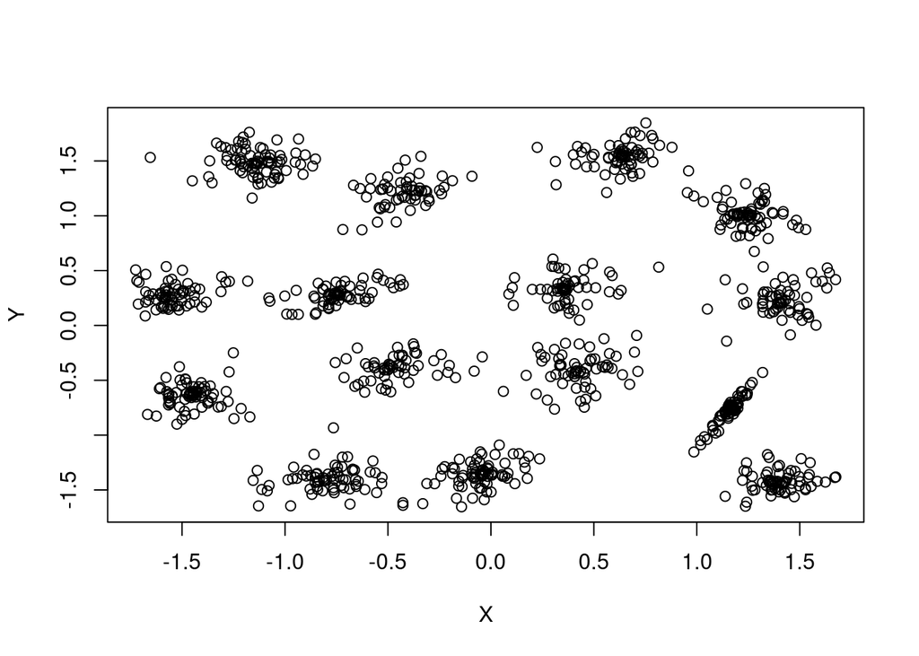

```r
input <- read.csv('~/Desktop/s1.csv', sep = ' ', header = 0)[c(5, 9)]
prepared <- na.omit(data.frame(scale(input[!is.na(input),])))
dane <- prepared[sample(1:dim(prepared)[1], 1000),]
rownames(dane) <- NULL
colnames(dane) <- c('X', 'Y')
plot(dane)
```

# 2 Porównanie optymalnej liczby klastrów

```r
kmeans_model <- lapply(k, function(x){ kmeans(dane, x) })
kmeans_clust <- lapply(kmeans_model, function(x){ x$cluster })
kmeans_tot.withinss <- unlist(lapply(kmeans_model, function(x){ x$tot.withinss }))
kmeans_centroids <- lapply(kmeans_model, function(x){ x$centers })


pam_model <- lapply(k, function(x){ pam(dane, x) })
pam_clust <- lapply(pam_model, function(x){ x$clustering })
pam_objective <- data.frame(k, do.call(rbind, lapply(pam_model, function(x){ x$objective })))
pam_centroids <- lapply(pam_model, function(x){ x$medoids })
pam_melt <- melt(pam_objective, id.vars = 'k')
```

Porównanmy jakość naszych modeli dla $2, 3, ..., 30$ klastrów. Pamiętajmy, że optymalna liczba klastrów powinna wynosić 15, gdyż na tyle jest podzielony nasz zbiór.

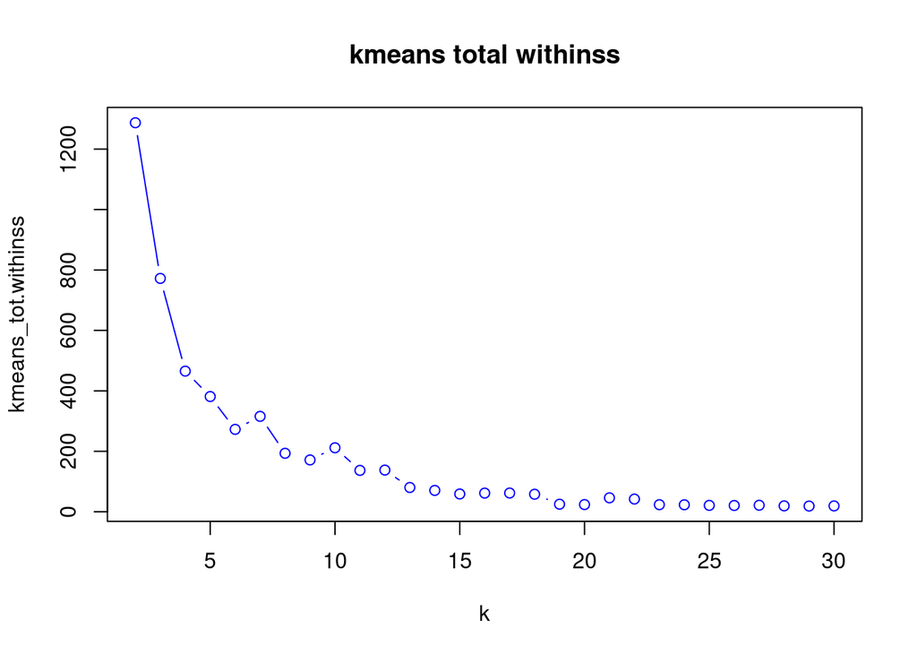

```r
plot(x = k, y = kmeans_tot.withinss, type = 'b', col = 'blue', main='kmeans total withinss')
```

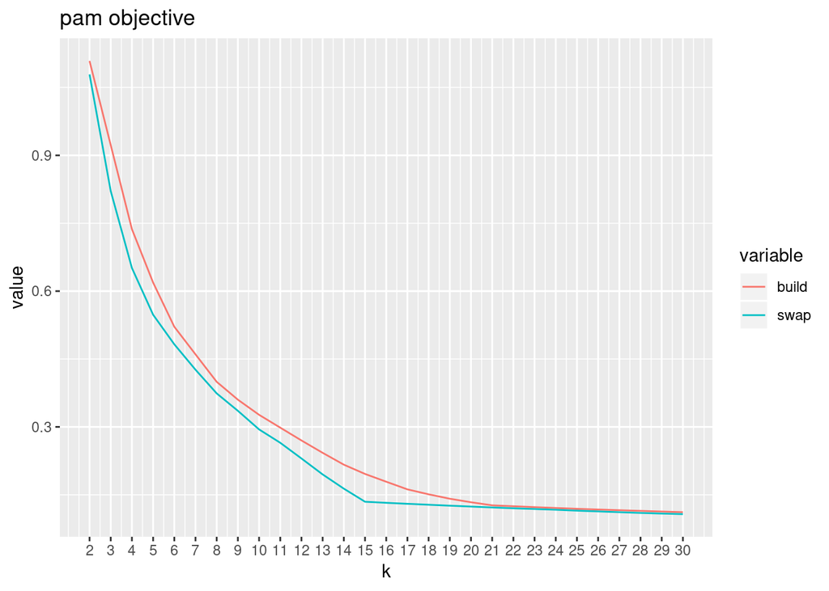

```r
ggplot(pam_melt, aes(x = k, y = value, fill=variable)) +
  scale_x_continuous(breaks = k) +
  geom_line(aes(colour = variable)) +
  ggtitle('pam objective')
```

`pam` ma dwie fazy budowy klastrów. Pierwsza `build` odnajduje szybko początkowy zestaw medoidów, a druga `swap` optymalizuje ich pozycje, aby zmniejszyć indeks `objective`. Ten proces widać na powyższym wykresie. `build` zarysowuje ogólną charakterystykę klasteryzacji, ale to dopiero `swap` dobrze dopasowuje klastry do punktów. Tutaj dokładnie widać, że $15$ jest optymalną liczbą klastrów. Sam wykres jest dużo gładszy niż w przypadku `kmeans` co może oznaczać, że `pam` przemyślanie buduje kolejne klastry i jednostajnie zbiega do optymalnego klastrowania.

# 3 Porównanie klastrowania

## 3.1 Klastry

[figure not shown]

```r
grid.arrange(
  fviz_cluster(kmeans_model[[14]], data = dane, ellipse.type = "convex")+
    theme_minimal() + labs(title = paste0("kmeans with ", 14, ' clusters')),
  fviz_cluster(pam_model[[14]], data = dane, ellipse.type = "convex")+
    theme_minimal() + labs(title = paste0("pam with ", 14, ' clusters')), nrow = 1)
```

Ta grafika potwierdza, że `kmeans` łączy klastry nieintuicynie, w sposób nieprzemyślany, brutalny. Klastry `pam` są niemalże idealne, odpowiadają naszej intuicji.

## 3.2 Centro/Medoidy

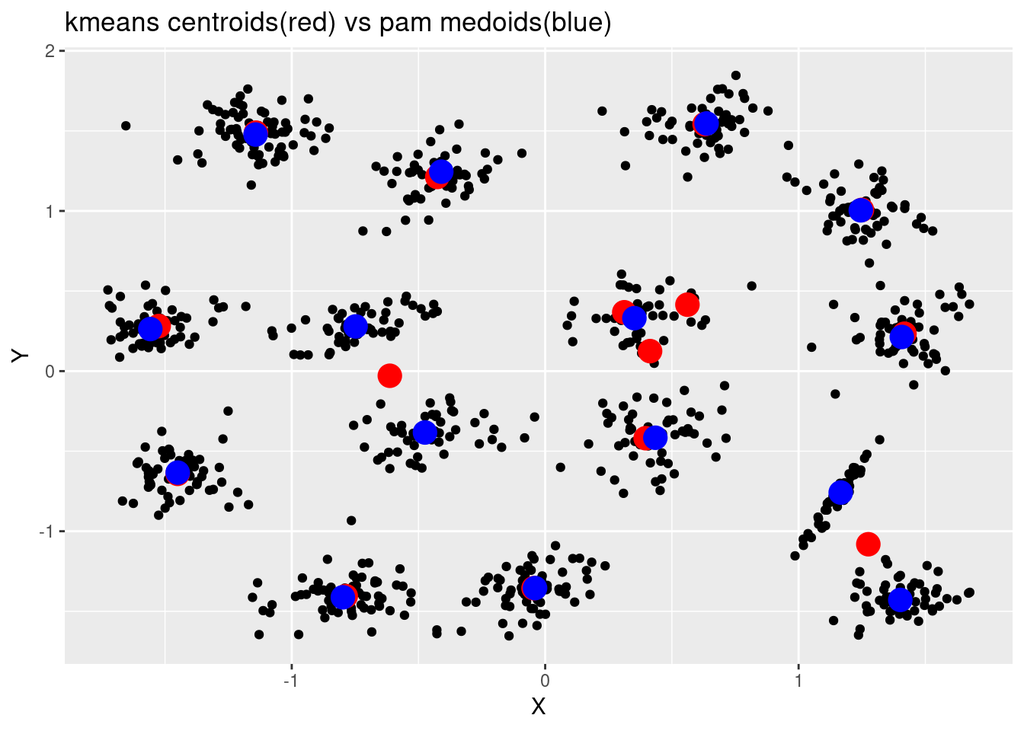

```r
centers <- data.frame(rbind(
  cbind(kmeans_centroids[[14]], rep('kmeans', dim(kmeans_centroids[[14]])[1])),
  cbind(pam_centroids[[14]], rep('pam', dim(pam_centroids[[14]])[1]))))
colnames(centers) <- c('X', 'Y', 'model')
rownames(centers) <- NULL


ggplot(dane, aes(x = X, y = Y)) +
  geom_point() +
  geom_point(data = data.frame(kmeans_centroids[[14]]), colour = 'red', size = 5) +
  geom_point(data = data.frame(pam_centroids[[14]]), colour = 'blue', size = 5) +
  ggtitle('kmeans centroids(red) vs pam medoids(blue)')
```

Medoidy `pam` trafiają bardzo precyzyjnie w najgęstsze obszary klastrów. Centroidy `kmeans` w większości przypadków nie są źle wymierzone, ale w niektórych przypadkach są nieintuicyjnie rozmieszczone.

# 4 Podsumowanie

`kmeans` w tym eksperymencie mnie nieco negatywnie zaskoczył. Jego działanie jest bardzo intuicyjne, ale jego klastry już mniej. `pam` osiągnął bardzo fajne wyniki, jego klastry były w naszym przypadku idealnie trafione. Zdecydowaną wadą `pam` jest to, że działa dużo dłużej od poczciwego `kmeans`. `kmeans` daje wyniki natychmiast, natomiast kwadratową złożoność `pam` da się bardzo odczuć. Bardzo alarmujący jest wykres łokciowy `kmeans`, gdzie widać, że model słabo dążył do optymalnej liczby klastrów. W tym przypadku, gdzie mieliśmy syntetyczny zbiór danych z widocznymi klastrami `pam` wypadł dużo lepiej od `kmeans`. Ciekawe jakby się ta zależność prezentowała gdyby nasze klastry były słabiej odseparowane.